## MA2102

# Probability and Statistics

#### Lecture-12

# Transformations

Let $X$ be a random variable defined on probability space $(\Omega,\mathscr{F},P)$, with probability distribution $P^X$, and we are often interested in a random variable $Y$ which is some transformation of $X$, say $Y=g(X)$, then $Y$ will be another random variable on $(\Omega,\mathscr{F},P)$

**Note**: Technically $g:\mathbb{R}\to\mathbb{R}$ should be Borel measurable function so that $Y=g(X)$ will be again a random variable on $(\Omega,\mathscr{F},P)$ (A function $f:\mathbb{R}\to\mathbb{R}$ is said to be Borel measurable function if $f^{-1}(B)\in\mathscr{B}~\forall B\in\mathscr{B}$)

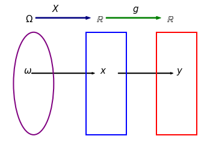

```python
import numpy as np
from matplotlib import patches
import matplotlib.pyplot as plt

fig = plt.figure()
ax = fig.subplots()


Omega = patches.Ellipse((0.14, 0.5), 0.2, 0.5,
                     angle=0, linewidth=2, fill=False, zorder=2,color='purple')

XR = patches.Rectangle((0.4, 0.25), 0.2, 0.5,
                     angle=0, linewidth=2, fill=False, zorder=2,color='blue')

gR = patches.Rectangle((0.75, 0.25), 0.2, 0.5,
                     angle=0, linewidth=2, fill=False, zorder=2,color='red')
ax.add_patch(Omega)
ax.add_patch(XR)
ax.add_patch(gR)

ax.text(0.1,0.8,r"$\Omega$",fontsize=15)
ax.text(0.45,0.8,r"$\mathbb{R}$",fontsize=15)
ax.text(0.8,0.8,r"$\mathbb{R}$",fontsize=15)

ax.arrow(0.15,0.82,0.25,0,width=0.005,color='navy')
ax.arrow(0.5,0.82,0.25,0,width=0.005,color='green')
ax.text(0.23,0.85,r"$X$",fontsize=15)
ax.text(0.63,0.85,r"$g$",fontsize=15)

ax.arrow(0.13,0.55,0.30,0,width=0.003,color='black')
ax.arrow(0.56,0.55,0.26,0,width=0.003,color='black')
ax.text(0.09,0.55,r"$\omega$",fontsize=15)
ax.text(0.47,0.55,r"$x$",fontsize=15)
ax.text(0.85,0.55,r"$y$",fontsize=15)
plt.axis('off')
plt.show()
```

Now, probability distribution of $Y$ can be obtained in terms of probability distribution of $X$

For $B\in \mathscr{B}$, $P^Y(B)=P(Y\in B)=P(g(X)\in B)$

$=P(X\in g^{-1}(B))=P^X(g^{-1}(B))$

$\therefore P^Y(B)=P^X(g^{-1}(B))$

### Transformations for discrete random variables:

If $X$ is discrete random variable with support $S_X$ and $PMF$ $p_X$, then $Y=g(X)$ will also be discrete random variable with support $S_Y=\{y\in\mathbb{R}:y=g(x), \text{for some} ~x\in S_X\}$

In this case we may be interested in $PMF$ of $Y$, $p_Y$

For, $y\in S_Y$, $p_Y(y)=P(Y=y)$

$=P(g(X)=y)$

$=P(X\in g^{-1}(\{y\}))$

$p_Y(y)=\sum_{x\in S_X;g(x)=y}P^X(\{x\})$ ($\because g^{-1}(\{y\})=\{x\in S_X:g(x)=y\}$)

If $g$ is one-one function then

For $y\in S_y$

$p_Y(y)=p_X(g^{-1}(y))$ ($\because$ $g^{-1}(\{y\})$ will have single pre-image that can be denoted by $g^{-1}(y)$)

**Example**:Let us consider the random experiment of tossing a coin with probability of head $p$, ($0<p<1$), until total of $r$ heads obtained

Sample space $\Omega=\{\underbrace{a_1a_2...a_{r+x-1}}_\text{r-1 H's & x T's}a_{r+x}:a_i\in\{H,T\}~a_{r+x}=H,x=0,1,2,3,...\}$

Let $X=$number of tails before the $r^{th}$ head

Then support of $X$, $S_X=\{0,1,2,3,...\}$

$PMF$ of $X$, $p_X(x)=P(X=x)$

$=\sum_{\omega\in\Omega;X(\omega)=x}P(\{\omega\})$

$=\sum_{\omega\in\Omega;X(\omega)=x}(1-p)^xp^r$

$p_X(x)=\binom{x+r-1}{r-1}(1-p)^xp^r$, for $x=0,1,2,3,..$ ------(1)

We can also express $p_X(x)$ as follows

$p_X(x)=(-1)^x\binom{-r}{x}(1-p)^xp^r$ for $x=0,1,2,3,..$ ----(2)  
($\because~\binom{x+r-1}{r-1}=\binom{r+x-1}{x}=(-1)^x\binom{-r}{x}$)

Here $X$ is said to have **Negative Binomial distribution**

now, let $Y=$number of trials required to get $r^{th}$ head

then, $Y=X+r$ (i.e $g(X)=X+r$ which is one-one)

Support of $Y$, $S_Y=\{r,r+1,r+2,...\}$

$X=Y-r=g^{-1}(Y)$

$PMF$ of $Y$, $p_Y(y)=p_X(g^{-1}(y))$

$=p_X(y-r)$

$p_Y(y)=\binom{y-r+r-1}{r-1}(1-p)^{y-r}p^r$ ($\because$ (1))

$p_Y(y)=\binom{y-1}{r-1}(1-p)^{y-r}p^r$ for $y=r,r+1,r+2,...$

**Example**:Let $X$ be the discrete random variable with support $S_X=\{1,2,3,4,...\}$

and $PMF$ $p_X(x)=\left(\frac{1}{2}\right)^x$, $x=1,2,3,...$

Take $Y=(X-2)^2$ (i.e $Y=g(X)$ where $g(X)=(X-2)^2$)

Here $g(x)$ is not one-one

$S_Y=\{0,1,4,9,16,...\}$

$PMF$ of $Y$,

$p_Y(y)=p_X(g^{-1}\{y\})=\left\{\begin{matrix} p_X(2) &y=0 \\ p_X(1)+p_X(3)&y=1 \\ p_X(\sqrt{y}+2) & y=4,9,16,... \end{matrix}\right.$

$p_Y(y)=\left\{\begin{matrix} \frac{1}{4} &y=0 \\ \frac{5}{8}&y=1 \\ \frac{1}{4}\left(\frac{1}{2}\right)^\sqrt{y} & y=4,9,16,... \end{matrix}\right.$

**Eaxmple:**

Let $X$ be a discrete random variable with $PMF$ $p_X(-1)=\frac{1}{3},p_X(0)=\frac{1}{4}$,and $p_X(1)=\frac{5}{12}$, and $Y=X^2$, Find the $PMF$ of $Y$.

*solution:* Here $S_X=\{-1,0,1\}$ and $Y=X^2$, i.e $g(X)=X^2$ which is not one-one, and $S_Y=\{0,1\}$

$PMF$ of $Y$, $p_y(0)=p_X(g^{-1}\{0\})$

$=p_X(0)=\frac{1}{4}$

$p_Y(1)=p_X(g^{-1}\{1\})$

$=p_X(-1)p_X(1)=\frac{1}{3}+\frac{5}{12}=\frac{3}{4}$

$\therefore$ $p_Y(0)=\frac{1}{4}$, $p_Y(1)=\frac{3}{4}$

### Transformations for continuous random variables:

Let $X$ be a continuous random variable with $PDF$ $f_X(x)$, and $Y=g(X)$, then we want to find $PDF$ of $Y$ using $PDF$ of $X$.

One way is, first obtain $CDF$ of $Y$, then we can obtain $PDF$ of $Y$ by differentiating $CDF$

$CDF$ of $Y$, $F_Y(y)=P(Y\le y)=P^Y((-\infty,y])=P^X(g^{-1}(-\infty,y])=\int_{g^{-1}(-\infty,y]}f_X(t)dt$

then, $PDF$ of $Y$, $f_Y(y)=\frac{d}{dy}F_Y(y)$

- Let $X$ be a continuous random variable with $PDF$ $f_X(x)$, and $CDF$ $F_X(x)$, $Y=X^2$, then $CDF$ of $Y$  
  for $y<0$, $F_Y(y)=P(Y\le y)=0$  
  for $y\ge 0$ $F_Y(y)=P(Y\le y)=P(X^2\le y)=P(|X|\le \sqrt{y})=P(-\sqrt{y}\le X\le \sqrt{y})$

In terms of $CDF$ of $X$, $F_Y(y)=\left\{\begin{matrix} 0&y<0 \\ F_X(\sqrt{y})-F_X(-\sqrt{y})& y\ge0 \end{matrix}\right.$ $=\left\{\begin{matrix} 0 & y<0\\ \int_{-\sqrt{y}}^{\sqrt{y}}f_X(x)dx& y\ge0 \end{matrix}\right. $

$PDF$ of $Y$, $f_Y(y)=\frac{d}{dy}F_Y(y)=\left\{\begin{matrix} 0&y<0 \\ \frac{d}{dy}(F_X(\sqrt{y})-F_X(-\sqrt{y}))& y\ge0 \end{matrix}\right.$

$=\left\{\begin{matrix} 0&y<0 \\ f_X(\sqrt{y})\frac{1}{2\sqrt{y}}-f_X(-\sqrt{y})\frac{-1}{2\sqrt{y}}& y\ge0 \end{matrix}\right.$

$f_Y(y)=\left\{\begin{matrix} 0&y<0 \\ \frac{f_X(\sqrt{y})+f_X(-\sqrt{y})}{2\sqrt{y}}& y\ge0 \end{matrix}\right.$

Further if $f_X(x)$ is even function(i.e $f_X(-x)=f_X(x)$),then

$f_Y(y)=\left\{\begin{matrix} 0&y<0 \\ \frac{f_X(\sqrt{y})}{\sqrt{y}}& y\ge0 \end{matrix}\right.$

**Example:** Let $X$ be a continuous random variable with $CDF$ $F_X(x)=\left\{\begin{matrix} 0&x<0 \\ x^2&0\le x<1 \\ 1& x\ge 1 \end{matrix}\right.$ Find the $PDF$ of $Y=X^2$

*Solution:*

First we find the $CDF$ of $Y$

$F_Y(y)=\left\{\begin{matrix} 0&y<0 \\ F_X(\sqrt{y})-F_X(-\sqrt{y})& y\ge0 \end{matrix}\right.$

if $0\le y<1\Rightarrow 0\le \sqrt{y}<1$, so $F_Y(y)=F_X(\sqrt{y})-F_X(-\sqrt{y})=(\sqrt{y})^2-0=y$

if $y\ge1\Rightarrow \sqrt{y}\ge1$, so $F_Y(y)=F_X(\sqrt{y})-F_X(-\sqrt{y})=1-0=1$

$\therefore$ the $CDF$ of $Y$, $F_Y(y)=\left\{\begin{matrix} 0&y<0 \\ y&0\le y<1 \\ 1& y\ge 1 \end{matrix}\right.$

now, $PDF$ of $Y$, $f_Y(y)=\frac{d}{dy}F_Y(y)=\left\{\begin{matrix} 1 &0<y<1 \\ 0& \text{otherwsie} \end{matrix}\right.$

$S_Y=(0,1)$

(Here $Y$ is said to have **Uniform distribution** over interval [0,1])

**Example**: Let $X$ be a continuous random variable with $PDF$ $f_X(x)=\left\{\begin{matrix} \frac{1}{2}&-1<x<1 \\ 0&\text{otherwise} \end{matrix}\right.$, then find the $PDF$ of $Y=X^2$

*solution:* Here $S_X=(-1,1)$

$CDF$ of $Y$,$F_Y(y)=\left\{\begin{matrix} 0 & y<0\\ \int_{-\sqrt{y}}^{\sqrt{y}}f_X(x)dx& y\ge0 \end{matrix}\right. $

if $0\le y<1\Rightarrow 0\le \sqrt{y}<1$, so $F_Y(y)=\int_{-\sqrt{y}}^{\sqrt{y}}\frac{1}{2}dx=\left[\frac{x}{2}\right]_{-\sqrt{y}}^{\sqrt{y}}=\frac{\sqrt{y}}{2}-\frac{-\sqrt{y}}{2}=\sqrt{y}$

if $y\ge1\Rightarrow \sqrt{y}\ge1$,

so $F_Y(y)=\int_{-\sqrt{y}}^{\sqrt{y}}f_X(x)dx=\int_{-\sqrt{y}}^{-1}0dx+\int_{-1}^{1}\frac{1}{2}dx+\int_{1}^{\sqrt{y}}0dx=0+\left[\frac{x}{2}\right]_{-1}^{1}+0=\frac{1}{2}-\frac{-1}{2}=1$

$\therefore$ the $CDF$ of $Y$, $F_Y(y)=\left\{\begin{matrix} 0&y<0 \\ \sqrt{y}&0\le y<1 \\ 1& y\ge 1 \end{matrix}\right.$

now, $PDF$ of $Y$, $f_Y(y)=\frac{d}{dy}F_Y(y)=\left\{\begin{matrix} \frac{1}{2\sqrt{y}} &0<y<1 \\ 0& \text{otherwsie} \end{matrix}\right.$

**Problem:** Let $X$ is a continuous random variable with $PDF$ $f_X(x)=\frac{1}{\sqrt{2\pi}}e^{\frac{-x^2}{2}}$,$-\infty<x<\infty$, then find $PDF$ of $Y=X^2$

(Here $X$ is said to have **Standard Normal distribution**)

Solution: Here support of $X$, $S_X=(-\infty,\infty)$, and $f_X(x)$ is even function

So, $PDF$ of $Y$, $f_Y(y)=\left\{\begin{matrix} 0&y<0 \\ \frac{f_X(\sqrt{y})}{\sqrt{y}}& y\ge0 \end{matrix}\right.$

$\frac{f_X(\sqrt{y})}{\sqrt{y}}=\frac{\frac{1}{\sqrt{2\pi}}e^{\frac{-{\sqrt{y}}^2}{2}}}{\sqrt{y}}$

$=\frac{1}{\sqrt{2\pi y}}e^{\frac{-y}{2}}=\frac{1}{\sqrt{\pi}}\frac{1}{2}\left(\frac{y}{2}\right)^{\frac{1}{2}-1}e^{\frac{-y}{2}}$

$=\frac{\frac{1}{2}\left(\frac{y}{2}\right)^{\frac{1}{2}-1}e^{\frac{-y}{2}}}{\Gamma \left(\frac{1}{2} \right)}$ ($\because~\Gamma \left(\frac{1}{2} \right)=\sqrt{\pi}$)

$f_Y(y)=\left\{\begin{matrix} 0&y<0 \\ \frac{\frac{1}{2}\left(\frac{y}{2}\right)^{\frac{1}{2}-1}e^{\frac{-y}{2}}}{\Gamma \left(\frac{1}{2} \right)}& y\ge0 \end{matrix}\right.$

(Here $Y$ is said to have **Chi-squared distribution** with 1 degree of freedom)

**Theorem:** Let $X$ be a continuous random variable with $PDF$ $f_X(x)$ and support $S_X$. Let $y=g(X)$, where $g(x)$is one-one differentiable function on $S_X$, then the $PDF$ of $Y$ is given by $f_Y(y)=f_X(g^{-1}(y))\begin{vmatrix} \frac{d(g^{-1}(y))}{dy} \end{vmatrix}$, for $y\in S_Y=\{y:y=g(x), \text{for some}~ x\in S_X\}$

*proof:* $g(x)$ is either strictly increasing or strictly decreasing as $g(x)$ is one-one function

**case-i:** $g(x)$ is strictly increasing

$CDF$ of $Y$, $F_Y(y)=P(Y\le y)$

$=P(g(X)\le y)$

$=P(g^{-1}(g(X))\le g^{-1}(y))$ ($\because$ $g(x)\nearrow$$\Leftrightarrow$ $g^{-1}(x)\nearrow$)

$=P(X\le g^{-1}(y))=F_X(g^{-1}(y))$

$\therefore F_Y(y)=F_X(g^{-1}(y))$

now, $PDF$ of $Y$, $f_Y(y)=\frac{d}{dy}F_Y(y)=\frac{d}{dy}\left(F_X(g^{-1}(y))\right)$

$f_Y(y)=f_X(g^{-1}(y))\frac{d(g^{-1}(y))}{dy}$ ($\because$ $\frac{d}{dx}F_X(x)=f_X(x)$, and Chain Rule)

Here $g\nearrow$$\Leftrightarrow$ $g^{-1}\nearrow \Rightarrow \frac{d}{dy}(g^{-1}(y))>0$

$\therefore$ $f_Y(y)=f_X(g^{-1}(y))\begin{vmatrix} \frac{d(g^{-1}(y))}{dy} \end{vmatrix}$,$y\in S_Y$

**case-ii:** $g(x)$ is strictly decreasing

$CDF$ of $Y$, $F_Y(y)=P(Y\le y)$

$=P(g(X)\le y)$

$=P(g^{-1}(g(X))\ge g^{-1}(y))$ ($\because$ $g(x)\searrow$$\Leftrightarrow$ $g^{-1}(x)\searrow$)

$=P(X\ge g^{-1}(y))=1-P(X< g^{-1}(y))=1-P(X\le g^{-1}(y))$ ($\because$ $X$ is continuous random variable)

$\therefore F_Y(y)=1-F_X(g^{-1}(y))$

now, $PDF$ of $Y$, $f_Y(y)=\frac{d}{dy}F_Y(y)=\frac{d}{dy}\left(1-F_X(g^{-1}(y))\right)=\left(0-\frac{d}{dy}F_X(g^{-1}(y))\right)$

$f_Y(y)=-f_X(g^{-1}(y))\frac{d(g^{-1}(y))}{dy}$ ($\because$ $\frac{d}{dx}F_X(x)=f_X(x)$, and Chain Rule)

Here $g\searrow$$\Leftrightarrow$ $g^{-1}\searrow \Rightarrow \frac{d}{dy}(g^{-1}(y))<0$

$\therefore$ $f_Y(y)=f_X(g^{-1}(y))\begin{vmatrix} \frac{d(g^{-1}(y))}{dy} \end{vmatrix}$,$y\in S_Y$

Here $\frac{d(g^{-1}(y))}{dy}$ is called (one variable) **Jacobian** of inverse transformation $x=g^{-1}(y)$

**Example**: Let $X$ be a continuous random variable with $PDF$ $f_X(x)=\left\{\begin{matrix} 1& 0<x<1 \\ 0 & \text{otherwise} \end{matrix}\right.$. Find the $PDF$ of $Y=-2logX$

solution: Here $S_X=(0,1)$, $Y=-2logX$, i.e here $g(x)=-2logx$ which is one-one differentiable function

$y=-2logx$ $\Rightarrow$ $x=g^{-1}(y)=e^\frac{-y}{2}$

$S_Y=\{y\in\mathbb{R}:y=g(x), \text{for some} ~x\in S_X\}=[0,\infty)$

$\frac{d(g^{-1}(y))}{dy}=\frac{-1}{2}e^{\frac{-y}{2}}$

$\therefore$ $f_Y(y)=f_X(g^{-1}(y))\begin{vmatrix} \frac{d(g^{-1}(y))}{dy} \end{vmatrix}$, $y\in S_Y$

$\therefore$ $f_Y(y)=1\times\begin{vmatrix}\frac{-1}{2}e^{\frac{-y}{2}}\end{vmatrix}, y\in S_Y$

$\therefore$ $f_Y(y)=\left\{\begin{matrix} \frac{1}{2}e^{\frac{-y}{2}} & y\ge0 \\ 0 & y<0 \end{matrix}\right.$

Here $Y$ is said to have **Exponential distribution** with rate parameter $\lambda=\frac{1}{2}$

**Example:** Let $X$ be a continuous random variable with $PDF$ $f_X(x)=\left\{\begin{matrix} \frac{1}{\pi}& \frac{-\pi}{2}<x<\frac{\pi}{2} \\ 0 & \text{otherwise} \end{matrix}\right.$. Find the $PDF$ of $Y=tanX$

*Solution:* Here $S_X=\left(\frac{-\pi}{2},\frac{\pi}{2}\right)$, $Y=tanX$, so $S_Y=(-\infty,\infty)$

and $g(x)=tanx$ is one-one differentiable function $S_X$

$y=tanx$ $\Rightarrow$ $x=g^{-1}(y)=tan^{-1}y$

$-\infty<y<\infty$ $\Leftrightarrow$ $\frac{-\pi}{2}<tan^{-1}y<\frac{\pi}{2}$

now, $f_Y(y)=f_X(g^{-1}(y))\begin{vmatrix} \frac{d(g^{-1}(y))}{dy} \end{vmatrix}$, $y\in S_Y$

$f_Y(y)=f_X(tan^{-1}(y))\begin{vmatrix} \frac{d(tan^{-1}(y))}{dy} \end{vmatrix}$

$=\frac{1}{\pi}\times \begin{vmatrix} \frac{1}{1+y^2} \end{vmatrix}$, $-\infty<y<\infty$

$f_Y(y)=\frac{1}{\pi} \frac{1}{1+y^2}$, $-\infty<y<\infty$

(Here $Y$ is said to have **Cachy distribution**)

$\therefore$ $g(x)=x^n$ is one-one on $S_X$

$y=g(x)=x^n$ $\Rightarrow$ $g^{-1}(y)=y^\frac{1}{n}$

$\frac{d}{dy}\left(g^{-1}(y)\right)=\frac{1}{n}y^{\frac{1}{n}-1}$

now, $f_Y(y)=f_X(g^{-1}(y))\begin{vmatrix} \frac{d(g^{-1}(y))}{dy} \end{vmatrix}$, $y\in S_Y$

$f_Y(y)=f_X(y^\frac{1}{n})\begin{vmatrix} \frac{d\left(y^\frac{1}{n}\right)}{dy} \end{vmatrix}$

$\therefore f_Y(y)=\frac{1}{n}y^{\frac{1-n}{n}}f_X(y^{\frac{1}{n}})$